# Modeling and prediction for movies

## Setup

### Load packages

```r
# Loading libraries

library(ggplot2)
library(dplyr)
library(statsr)
library(GGally)
library(stringr)
library(e1071)
library(lubridate)
library(standardize)
library(kableExtra)
```

### Load data

```r
# Loading data

load("movies.Rdata")
```

## Part 1: Data

The data set is comprised of 651 randomly sampled movies produced and released before 2016. This data (audience & critics rating) was collected through a survey and includes information from Rotten Tomatoes and IMDB. Thus it is an **Observational study & we cannot establish causality**

Since the audience & critics provided their rating voluntarily, the study would be affected by volunteer bias and hence cannot be generalized for the population of all the movies released & produced till date.

## Part 2: Research question

The research question is split into 2 parts:

1. What attributes make a movie popular?
2. Establishing a prediction model

Popularity of a movie can be represented / gauged in a number of ways. It is the people’s choice that makes a movie popular & directly affects its earnings than that of the critics. Hence the rating provided by audience, as measured by **imdb_rating** & **audience_score**, shall be used to define a movie’s popularity.

## Part 3: Exploratory data analysis

**SELECTION OF VARIABLES**

Though a movie’s popularity may be attributed to the Director / lead actors of the movie, these variables exhibit a wide range & hence cannot be included into the analysis. Thus variables such as **director**, **actor1**, **actor2**, **actor3**, **actor4** & **actor5** are dropped.

Next, variables which are known to be correlated are dropped:

1. **critics_rating** & **audience_rating**: These variables are just the categorical formats of **critics_score** & **audience_score** respectively & are hence dropped.
2. **best_pic_win**: The data captured by this variable is already captured in **best_pic_nom** & since it is known that all popular movies do not win an oscar, this variable is dropped.
3. **dvd_rel_year**: Since the movies are first released in the theaters & then after a period of time released on DVD’s, this variable needs to be positively correlated to **thtr_rel_year**.

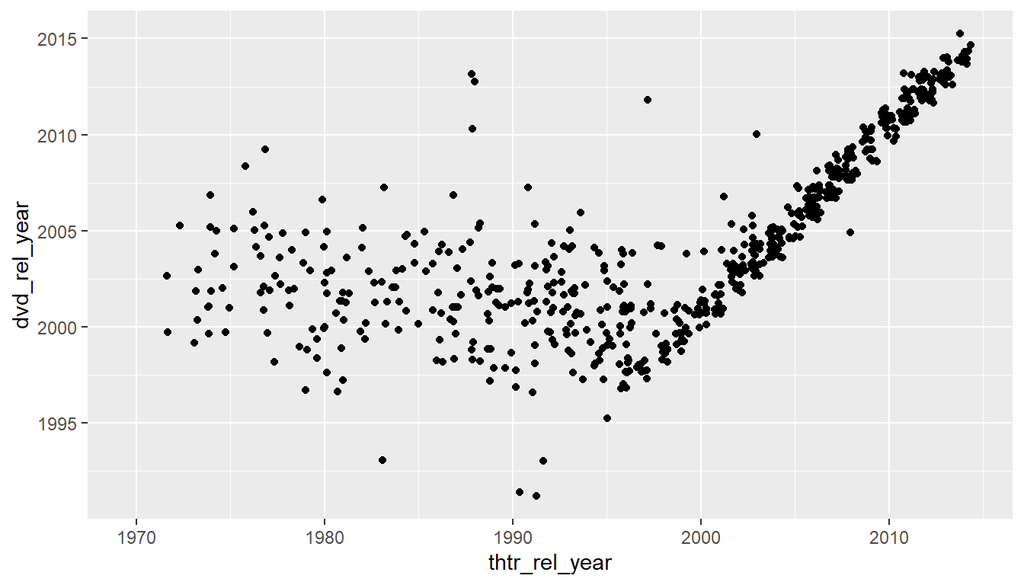

As per the article, [History of DVD](https://didyouknow.org/dvdhistory/), DVD technology became commercially available in 1996 but was initially expensive. It was only after the year 2000 as per [Wikipedia](https://en.wikipedia.org/wiki/DVD_player#:~:text=The%20first%20DVD%2DAudio%20players,2000%20for%20%24700%20to%20%241%2C200.), when the cost of DVD players dropped from approx. 1000 USD to under 100 USD leading to sky-rocketing of sales of DVD & DVD players.

This explains the random scatter of data until the start of 2000 post which a strong correlation between the two variables is evident. Hence the variable, **dvd_rel_year**, is dropped as well.

A new dataset, **df1**, with all the non-essential variables dropped, is created.

```
## tibble [651 x 13] (S3: tbl_df/tbl/data.frame)
##  $ studio          : Factor w/ 211 levels "20th Century Fox",..: 91 202 167 34 13 163 147 118 88 84 ...
##  $ thtr_rel_year   : num [1:651] 2013 2001 1996 1993 2004 ...
##  $ thtr_rel_month  : num [1:651] 4 3 8 10 9 1 1 11 9 3 ...
##  $ thtr_rel_day    : num [1:651] 19 14 21 1 10 15 1 8 7 2 ...
##  $ imdb_rating     : num [1:651] 5.5 7.3 7.6 7.2 5.1 7.8 7.2 5.5 7.5 6.6 ...
##  $ imdb_num_votes  : int [1:651] 899 12285 22381 35096 2386 333 5016 2272 880 12496 ...
##  $ critics_score   : num [1:651] 45 96 91 80 33 91 57 17 90 83 ...
##  $ audience_score  : num [1:651] 73 81 91 76 27 86 76 47 89 66 ...
##  $ best_pic_nom    : Factor w/ 2 levels "no","yes": 1 1 1 1 1 1 1 1 1 1 ...
##  $ best_actor_win  : Factor w/ 2 levels "no","yes": 1 1 1 2 1 1 1 2 1 1 ...
##  $ best_actress_win: Factor w/ 2 levels "no","yes": 1 1 1 1 1 1 1 1 1 1 ...
##  $ best_dir_win    : Factor w/ 2 levels "no","yes": 1 1 1 2 1 1 1 1 1 1 ...
##  $ title           : chr [1:651] "Filly Brown" "The Dish" "Waiting for Guffman" "The Age of Innocence" ...
```

Studying the structure of the reduced dataset, following steps were taken:

1. The 2 variables, **imdb_rating** & **audience_score**, are combined to create a new variable, **popularity_rating**, which measures the popularity of the movie on the scale of 0 to 10. This is the **dependent variable.**
2. The studio variable consisting of 211 levels is reduced to the following 3 sub-types:
   1. **Top 5**: If the movie Studio is considered to be the top 5 studios in the world.
   2. **Top 10**: If the movie Studio is considered to be the top 6th to 10th studios in the world.
   3. **“Not in top 10”**: If the movie Studio fails to fall in the first 2 categories.
3. Movie makers usually prefer to release movies around the holiday season which include Summer & Autumn. To include this into the study, the variable **thtr_rel_month** which represents the release month as a numerical variable is converted into a categorical variable **thtr_rel_season**.
4. Weekend releases boosts the sales of the tickets which eventually decides the earnings of a movie & could contribute to a movie’s popularity. Thus a weekend release might also be a governing factor. To include this aspect into the study, the variable **thtr_rel_day** is converted into a two-level categorical variable, **week_day** labelling them as follows:
   1. **Weekend_release:** For movies released on Friday, Saturday or Sunday.
   2. **Weekday_release:** For movies released on Monday through Thursday.

**CHECK FOR MULTI-COLLINEARITY:**

Next the numerical variables are checked for their distribution & to see if they are correlated to each other.

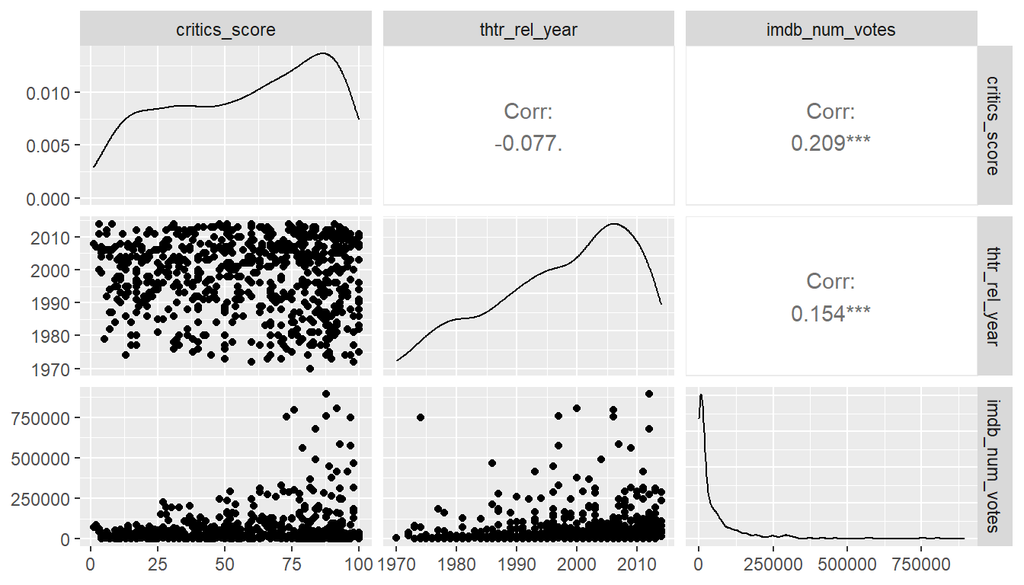

The plot reveals correlation between the variables **imdb_num_votes** & **critics_score** & **thtr_rel_year**. The plot also reveals that the variable **imdb_num_votes** is highly right skewed. Since regression analysis is carried out based on the mean value of a variable and since the mean is (usually) not a good measure of central tendency in a skewed distribution, using the variable **imdb_num_votes**, as is, may make the regression results rather inappropriate.

Hence instead of outright rejecting it, a log transformation is applied & the condition for collinearity is re-checked.

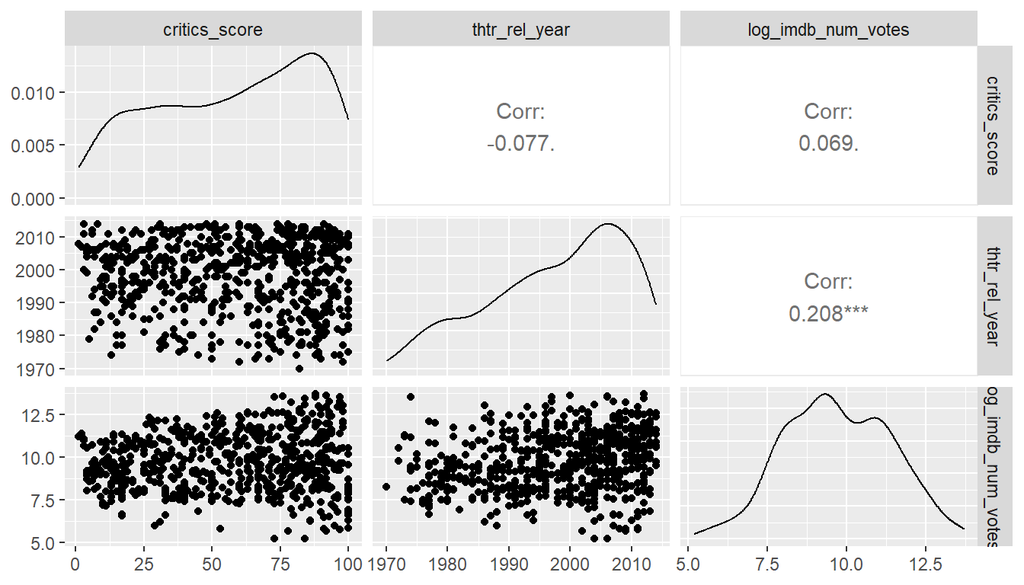

Post the transformation it can be seen that the **log_imdb_num_votes** looks to be normally distributed & is still correlated with **thtr_rel_year**. Since the **thtr_rel_year** should not be a governing factor that makes a movie popular, this variable is dropped.

## Part 4: Modeling

Now that all the variables are in the form as required for the analysis, we can proceed with research questions at hand.

**Research question 1: What attributes make a movie popular?**

For arriving at the significant attributes, the **Backward substitution using p-value** method is used. Starting with the Full model, variables are dropped based on their significance level.

## Full Model

```
##
## Call:
## lm(formula = popularity_rating ~ critics_score + studio_rating +
##     thtr_rel_season + week_day + log_imdb_num_votes + best_pic_nom +
##     best_actor_win + best_actress_win + best_dir_win, data = df1)
##
## Residuals:
##     Min      1Q  Median      3Q     Max
## -2.6707 -0.6207 -0.0062  0.6477  3.3049
##
## Coefficients:
##                          Estimate Std. Error t value Pr(>|t|)
## (Intercept)              2.993402   0.259530  11.534  < 2e-16 ***
## critics_score            0.038260   0.001433  26.701  < 2e-16 ***
## studio_ratingTop 10     -0.216462   0.109334  -1.980   0.0482 *
## studio_ratingTop 5      -0.051012   0.090424  -0.564   0.5729
## thtr_rel_seasonSpring   -0.073968   0.111385  -0.664   0.5069
## thtr_rel_seasonSummer   -0.107285   0.107947  -0.994   0.3207
## thtr_rel_seasonWinter    0.108876   0.105980   1.027   0.3047
## week_dayWeekend_release -0.086367   0.096461  -0.895   0.3709
## log_imdb_num_votes       0.137362   0.024982   5.499 5.57e-08 ***
## best_pic_nomyes          0.432776   0.227584   1.902   0.0577 .
## best_actor_winyes       -0.109484   0.113856  -0.962   0.3366
## best_actress_winyes     -0.120926   0.125040  -0.967   0.3339
## best_dir_winyes         -0.114047   0.158525  -0.719   0.4721
## ---
## Signif. codes:  0 '***' 0.001 '**' 0.01 '*' 0.05 '.' 0.1 ' ' 1
##
## Residual standard error: 0.9677 on 630 degrees of freedom
## Multiple R-squared:  0.594,  Adjusted R-squared:  0.5863
## F-statistic: 76.81 on 12 and 630 DF,  p-value: < 2.2e-16
```

From the summary table, it can be seen that the variable **best_dir_win** has the highest p-value of **0.4721** & is hence dropped.

**ITERATION 1:**

```
##
## Call:
## lm(formula = popularity_rating ~ critics_score + studio_rating +
##     thtr_rel_season + week_day + log_imdb_num_votes + best_pic_nom +
##     best_actor_win + best_actress_win, data = df1)
##
## Residuals:
##     Min      1Q  Median      3Q     Max
## -2.6634 -0.6167 -0.0081  0.6377  3.3019
##
## Coefficients:
##                          Estimate Std. Error t value Pr(>|t|)
## (Intercept)              3.014713   0.257735  11.697  < 2e-16 ***
## critics_score            0.038158   0.001425  26.771  < 2e-16 ***
## studio_ratingTop 10     -0.216726   0.109292  -1.983   0.0478 *
## studio_ratingTop 5      -0.053370   0.090330  -0.591   0.5548
## thtr_rel_seasonSpring   -0.072088   0.111312  -0.648   0.5175
## thtr_rel_seasonSummer   -0.110359   0.107822  -1.024   0.3064
## thtr_rel_seasonWinter    0.108941   0.105940   1.028   0.3042
## week_dayWeekend_release -0.083203   0.096324  -0.864   0.3880
## log_imdb_num_votes       0.135017   0.024759   5.453  7.1e-08 ***
## best_pic_nomyes          0.419486   0.226747   1.850   0.0648 .
## best_actor_winyes       -0.114500   0.113599  -1.008   0.3139
## best_actress_winyes     -0.123686   0.124933  -0.990   0.3225
## ---
## Signif. codes:  0 '***' 0.001 '**' 0.01 '*' 0.05 '.' 0.1 ' ' 1
##
## Residual standard error: 0.9673 on 631 degrees of freedom
## Multiple R-squared:  0.5937, Adjusted R-squared:  0.5866
## F-statistic: 83.81 on 11 and 631 DF,  p-value: < 2.2e-16
```

From the summary table, it can be seen that the variable **week_day** has the highest p-value of **0.3880** & is hence dropped.

**ITERATION 2:**

```
##
## Call:
## lm(formula = popularity_rating ~ critics_score + studio_rating +
##     thtr_rel_season + log_imdb_num_votes + best_pic_nom + best_actor_win +
##     best_actress_win, data = df1)
##
## Residuals:
##     Min      1Q  Median      3Q     Max
## -2.5903 -0.6241 -0.0057  0.6411  3.2947
##
## Coefficients:
##                       Estimate Std. Error t value Pr(>|t|)
## (Intercept)            2.95282    0.24753  11.929  < 2e-16 ***
## critics_score          0.03834    0.00141  27.189  < 2e-16 ***
## studio_ratingTop 10   -0.21701    0.10927  -1.986   0.0475 *
## studio_ratingTop 5    -0.05325    0.09031  -0.590   0.5557
## thtr_rel_seasonSpring -0.07781    0.11109  -0.700   0.4839
## thtr_rel_seasonSummer -0.10733    0.10774  -0.996   0.3195
## thtr_rel_seasonWinter  0.11568    0.10563   1.095   0.2739
## log_imdb_num_votes     0.13337    0.02468   5.404 9.25e-08 ***
## best_pic_nomyes        0.42218    0.22668   1.862   0.0630 .
## best_actor_winyes     -0.11766    0.11352  -1.037   0.3004
## best_actress_winyes   -0.11511    0.12451  -0.924   0.3556
## ---
## Signif. codes:  0 '***' 0.001 '**' 0.01 '*' 0.05 '.' 0.1 ' ' 1
##
## Residual standard error: 0.9671 on 632 degrees of freedom
## Multiple R-squared:  0.5932, Adjusted R-squared:  0.5868
## F-statistic: 92.16 on 10 and 632 DF,  p-value: < 2.2e-16
```

From the summary table, it can be seen that the variable **best_actress_win** has the highest p-value of **0.3556** & is hence dropped.

**ITERATION 3:**

```
##
## Call:
## lm(formula = popularity_rating ~ critics_score + studio_rating +
##     thtr_rel_season + log_imdb_num_votes + best_pic_nom + best_actor_win,
##     data = df1)
##
## Residuals:
##     Min      1Q  Median      3Q     Max
## -2.5799 -0.6107 -0.0057  0.6431  3.3028
##
## Coefficients:
##                       Estimate Std. Error t value Pr(>|t|)
## (Intercept)            2.95367    0.24750  11.934  < 2e-16 ***
## critics_score          0.03831    0.00141  27.178  < 2e-16 ***
## studio_ratingTop 10   -0.21926    0.10923  -2.007   0.0451 *
## studio_ratingTop 5    -0.05395    0.09030  -0.597   0.5504
## thtr_rel_seasonSpring -0.07545    0.11105  -0.679   0.4971
## thtr_rel_seasonSummer -0.10727    0.10773  -0.996   0.3198
## thtr_rel_seasonWinter  0.11649    0.10562   1.103   0.2705
## log_imdb_num_votes     0.13239    0.02465   5.370 1.11e-07 ***
## best_pic_nomyes        0.38810    0.22364   1.735   0.0832 .
## best_actor_winyes     -0.12798    0.11295  -1.133   0.2576
## ---
## Signif. codes:  0 '***' 0.001 '**' 0.01 '*' 0.05 '.' 0.1 ' ' 1
##
## Residual standard error: 0.967 on 633 degrees of freedom
## Multiple R-squared:  0.5926, Adjusted R-squared:  0.5869
## F-statistic: 102.3 on 9 and 633 DF,  p-value: < 2.2e-16
```

From the summary table, it can be seen that the variable **thtr_rel_season** has the highest p-value of **0.2705** & is hence dropped.

**ITERATION 4:**

```
##
## Call:
## lm(formula = popularity_rating ~ critics_score + studio_rating +
##     log_imdb_num_votes + best_pic_nom + best_actor_win, data = df1)
##
## Residuals:
##     Min      1Q  Median      3Q     Max
## -2.5936 -0.5943  0.0140  0.6605  3.3192
##
## Coefficients:
##                      Estimate Std. Error t value Pr(>|t|)
## (Intercept)          2.977788   0.241072  12.352  < 2e-16 ***
## critics_score        0.038346   0.001411  27.182  < 2e-16 ***
## studio_ratingTop 10 -0.218006   0.108962  -2.001   0.0458 *
## studio_ratingTop 5  -0.053332   0.090396  -0.590   0.5554
## log_imdb_num_votes   0.127862   0.024560   5.206 2.61e-07 ***
## best_pic_nomyes      0.451017   0.222186   2.030   0.0428 *
## best_actor_winyes   -0.111181   0.112023  -0.992   0.3213
## ---
## Signif. codes:  0 '***' 0.001 '**' 0.01 '*' 0.05 '.' 0.1 ' ' 1
##
## Residual standard error: 0.9686 on 636 degrees of freedom
## Multiple R-squared:  0.5894, Adjusted R-squared:  0.5855
## F-statistic: 152.1 on 6 and 636 DF,  p-value: < 2.2e-16
```

From the summary table, it can be seen that the variable **best_actor_win** has the highest p-value of **0.3213** & is hence dropped.

**ITERATION 5:**

```
##
## Call:
## lm(formula = popularity_rating ~ critics_score + studio_rating +
##     log_imdb_num_votes + best_pic_nom, data = df1)
##
## Residuals:
##     Min      1Q  Median      3Q     Max
## -2.6827 -0.5908  0.0129  0.6578  3.3286
##
## Coefficients:
##                      Estimate Std. Error t value Pr(>|t|)
## (Intercept)          2.988102   0.240845  12.407  < 2e-16 ***
## critics_score        0.038323   0.001411  27.170  < 2e-16 ***
## studio_ratingTop 10 -0.216243   0.108946  -1.985   0.0476 *
## studio_ratingTop 5  -0.061445   0.090024  -0.683   0.4951
## log_imdb_num_votes   0.125682   0.024462   5.138  3.7e-07 ***
## best_pic_nomyes      0.420469   0.220041   1.911   0.0565 .
## ---
## Signif. codes:  0 '***' 0.001 '**' 0.01 '*' 0.05 '.' 0.1 ' ' 1
##
## Residual standard error: 0.9686 on 637 degrees of freedom
## Multiple R-squared:  0.5887, Adjusted R-squared:  0.5855
## F-statistic: 182.4 on 5 and 637 DF,  p-value: < 2.2e-16
```

From the summary table, it can be seen that the variable **best_pic_nom** has the highest p-value of **0.0565** which is very close to the cut-off value of 0.05. Since it is known that the **best_pic_nom** does indeed affect a movie’s popularity, the analysis is stopped.

Next we check if the conditions for Linear regression are met:

**Condition 1: Linear relationship between (numeric) independent variables & dependent variable.**

This condition can be checked by plotting the residuals against each numerical variable. A random scatter of data without any pattern ensures that this condition is met.

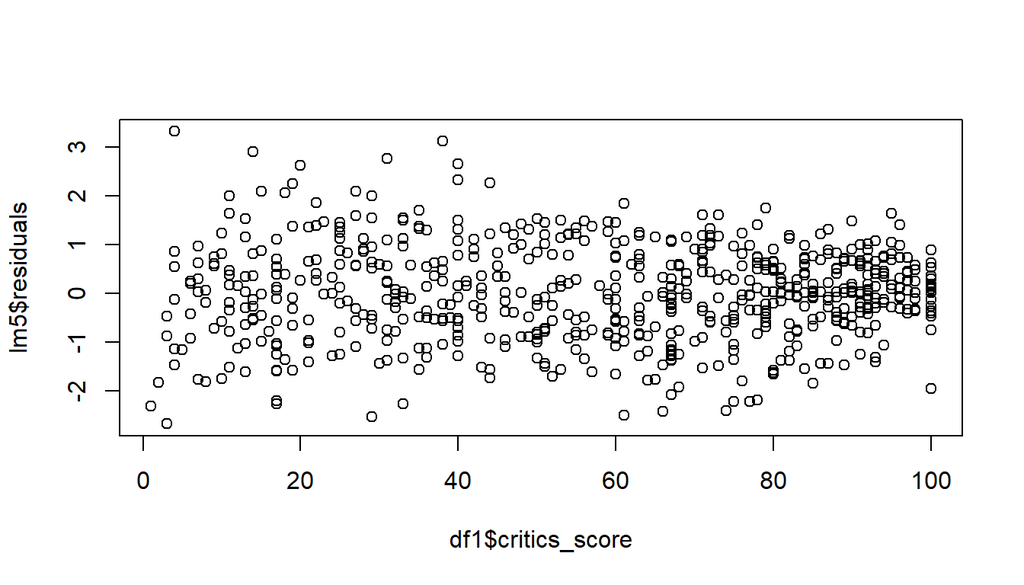

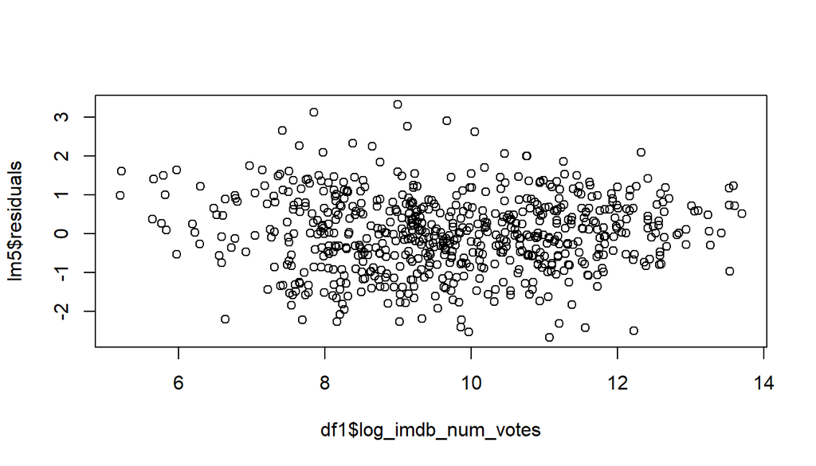

The two plots exhibit random variation, hence it can be concluded that this condition is met.

**Condition 2: Nearly normal residuals with mean 0**

This condition can be checked by:  
1. A histogram of residuals  
2. Normal plot along with the data on skewness

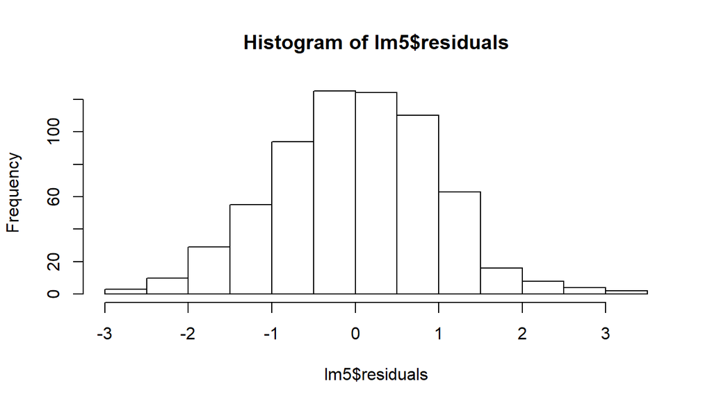

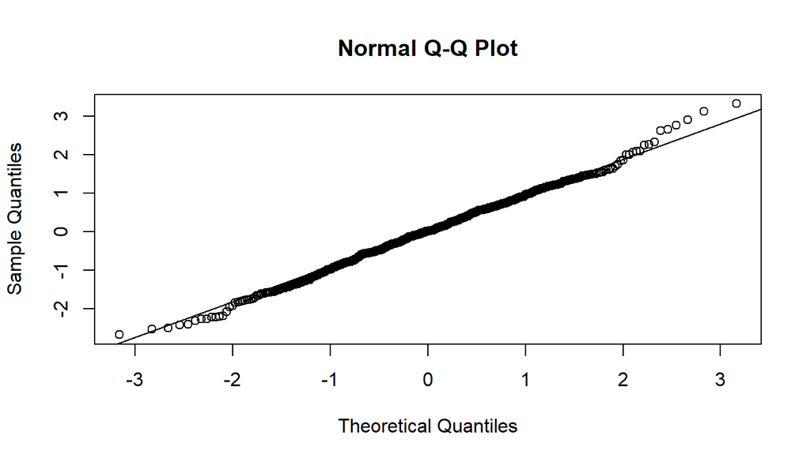

From the plots as well through the **skewness factor** of 0.0188 < 0.5, it evident that the residual is normally distributed with mean at 0.

**Condition 3: Constant variability of residuals**

This condition can be checked by looking at the residuals vs fitted plot. Absence of any pattern in the data would ensure that this condition is met.

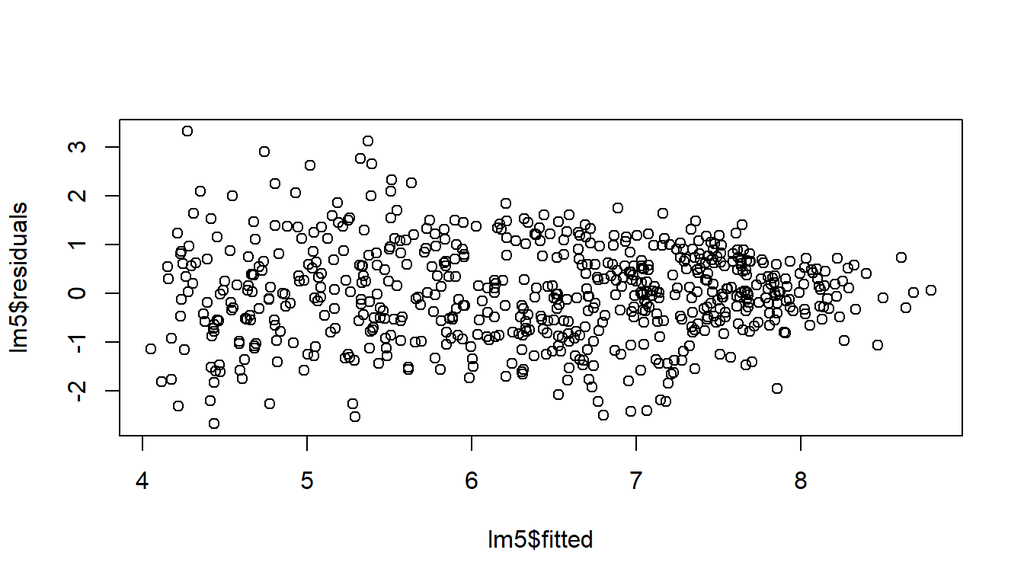

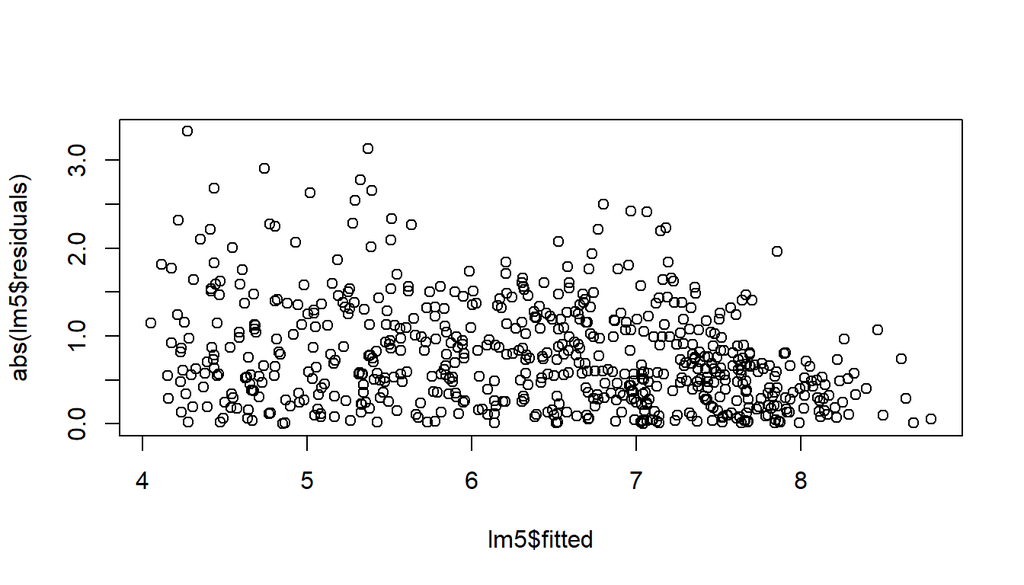

From the two plots it is evident that it is a **Fanning-type pattern** plot. Hence this condition is violated.

**Condition 4: Residuals are independent**

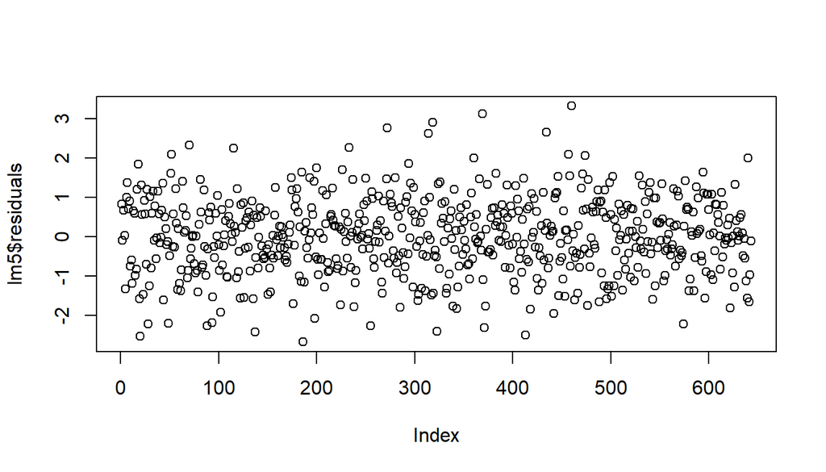

The plot shows a random distribution and since the samples were randomly selected & # of observations of 651 movies is less than 10% of the total # of movies produced until 2016, this condition is met as well.

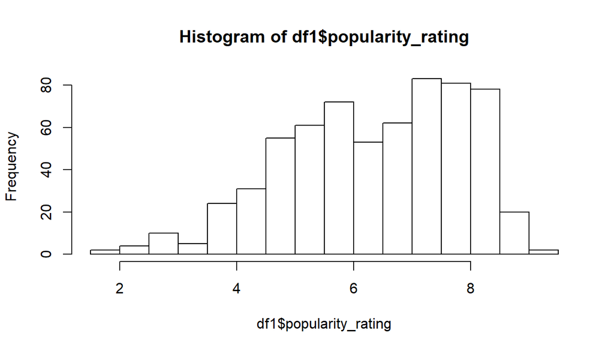

It is evident from the plot that the data is left-skewed which can be fixed by performing a squared transformation.

A quick check is done to see if the remaining conditions are met as well.

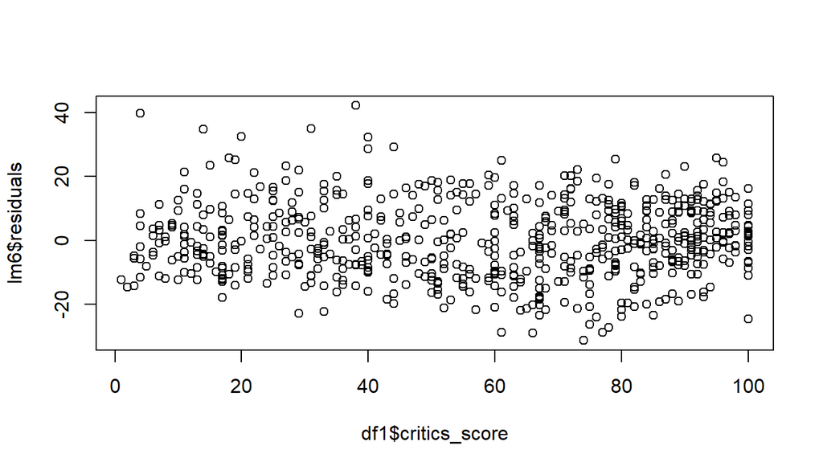

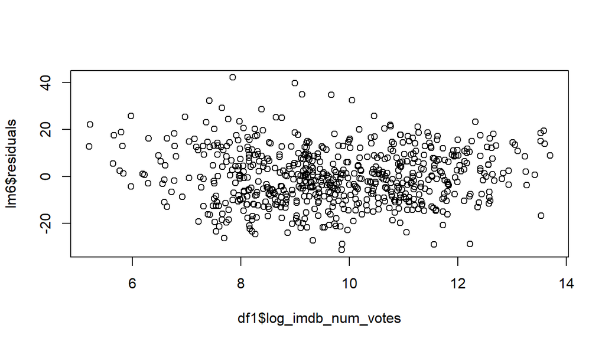

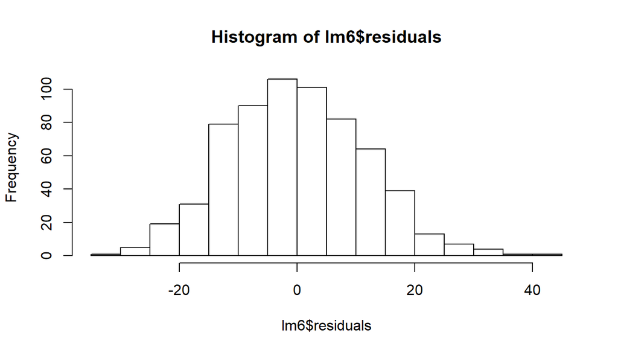

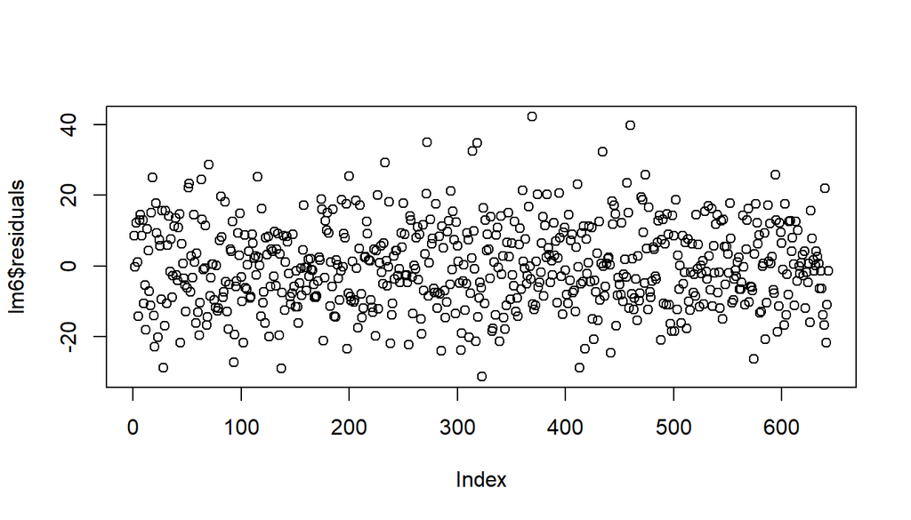

[figure not shown]

[figure not shown]

[figure not shown]

[figure not shown]

From the above plot it is clear that all the conditions are met and hence the model fits the dataset.

## Part 6.1: Conclusion

It is seen from the analysis that **critics_score, studio_rating, imdb_num_votes & best_pic_nom** seem to be the critical attributes that make a movie popular.

**Research question 2: Establishing a prediction model**

Since we are interested in creating a **Prediction model**, the **Adjusted R-squared** criterion shall be used to finalize the variables to be included in the model.

Thus, the Adj. R-squared value for the Full model is **0.5863**.

**ITERATION 1:**

Next we drop 1 variable at a time & check for the **Adj. R-squared value.**

| ADJUSTED R-SQUARED: FULL MODEL = 0.5863 | ADJUSTED R-SQUARED: FULL MODEL = 0.5863 Variable excluded | ADJUSTED R-SQUARED: FULL MODEL = 0.5863 Adj. R-sq value |
| --- | --- | --- |
| A | critics_score | 0.1195 |
| B | studio_rating | 0.585 |
| C | thtr_rel_season | 0.5852 |
| D | week_day | 0.5864 |
| E | log_imdb_num_votes | 0.5671 |
| F | best_pic_nom | 0.5846 |
| G | best_actor_win | 0.5863 |
| H | best_actress_win | 0.5863 |
| I | best_dir_win | 0.5866 |

From the above table, it is clear that dropping the variable **best_dir_win** gives the highest Adj. R-squared of **0.5866** & is hence dropped.

**ITERATION 2:**

[output not shown]

From the above table, it is clear that dropping the variable **week_day** gives the highest Adj. R-squared of **0.5868** & is hence dropped.

**ITERATION 3:**

| ADJUSTED R-SQUARED: FULL MODEL = 0.5868 | ADJUSTED R-SQUARED: FULL MODEL = 0.5868 Variable excluded | ADJUSTED R-SQUARED: FULL MODEL = 0.5868 Adj. R-sq value |
| --- | --- | --- |
| A | critics_score | 0.1048 |
| B | studio_rating | 0.5854 |
| C | thtr_rel_season | 0.5854 |
| D | log_imdb_num_votes | 0.5684 |
| E | best_pic_nom | 0.5851 |
| F | best_actor_win | 0.5867 |
| G | best_actress_win | 0.5869 |

From the above table, it is clear that dropping the variable **best_actress_win** gives the highest Adj. R-squared of **0.5869** & is hence dropped.

**ITERATION 4:**

| ADJUSTED R-SQUARED: FULL MODEL = 0.5869 | ADJUSTED R-SQUARED: FULL MODEL = 0.5869 Variable excluded | ADJUSTED R-SQUARED: FULL MODEL = 0.5869 Adj. R-sq value |
| --- | --- | --- |
| A | critics_score | 0.1062 |
| B | studio_rating | 0.5855 |
| C | thtr_rel_season | 0.5855 |
| D | log_imdb_num_votes | 0.5687 |
| E | best_pic_nom | 0.5855 |
| F | best_actor_win | 0.5867 |

From the above table, it is clear there is no increase in Adj. R-squared value. Hence we can say that we have achieved our **Parsimonious model.**

Next we check if the conditions for Linear regression are met:

**Condition 1: Linear relationship between numerical independent variables & dependent variable.**

This condition can be checked by plotting the residuals against each numerical variable. A random scatter of data without any pattern ensures that this condition is met.

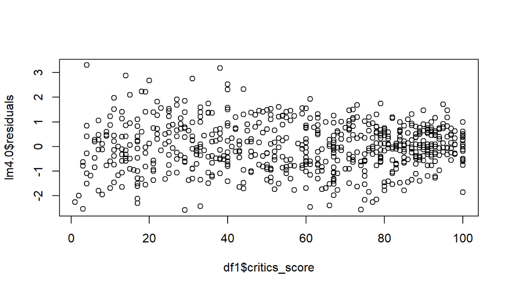

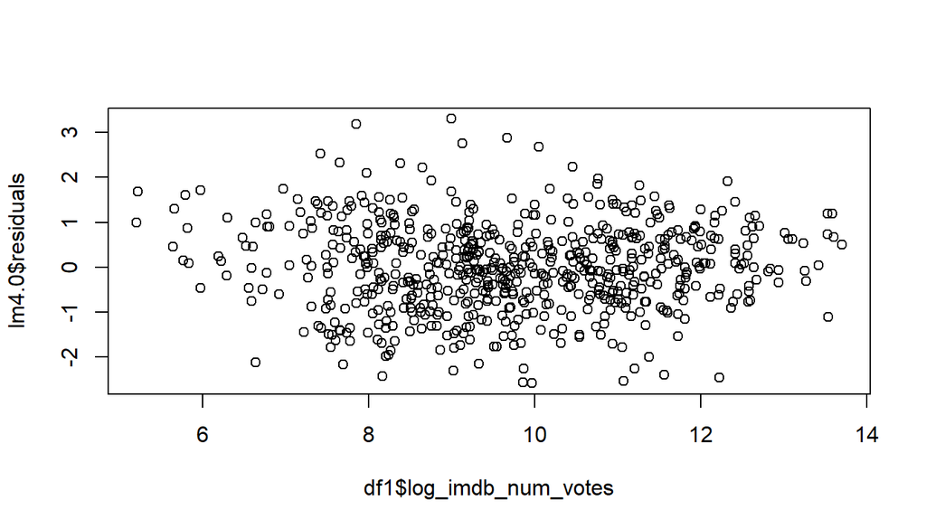

The two plots exhibit random variation, hence it can be concluded that this condition is met.

**Condition 2: Nearly normal residuals with mean 0**

This condition can be checked by: 1. A histogram of residuals 2. Normal plot along with the data on skewness

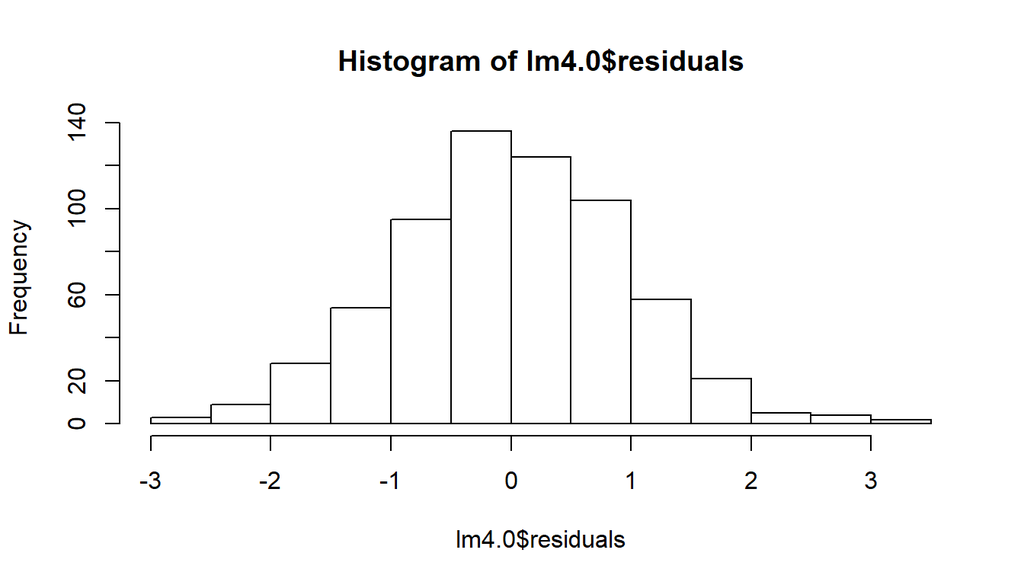

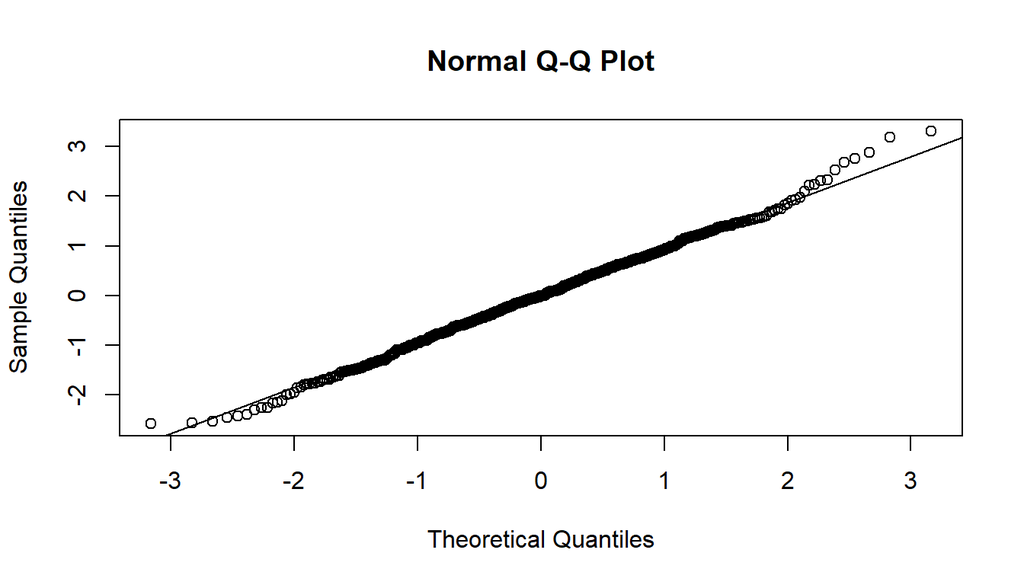

From the plots as well through the **skewness factor** of 0.0351 < 0.5, it evident that the residual is normally distributed with mean at 0.

**Condition 3: Constant variability of residuals**

This condition can be checked by looking at the residuals vs fitted plot. Absence of any pattern in the data would ensure that this condition is met.

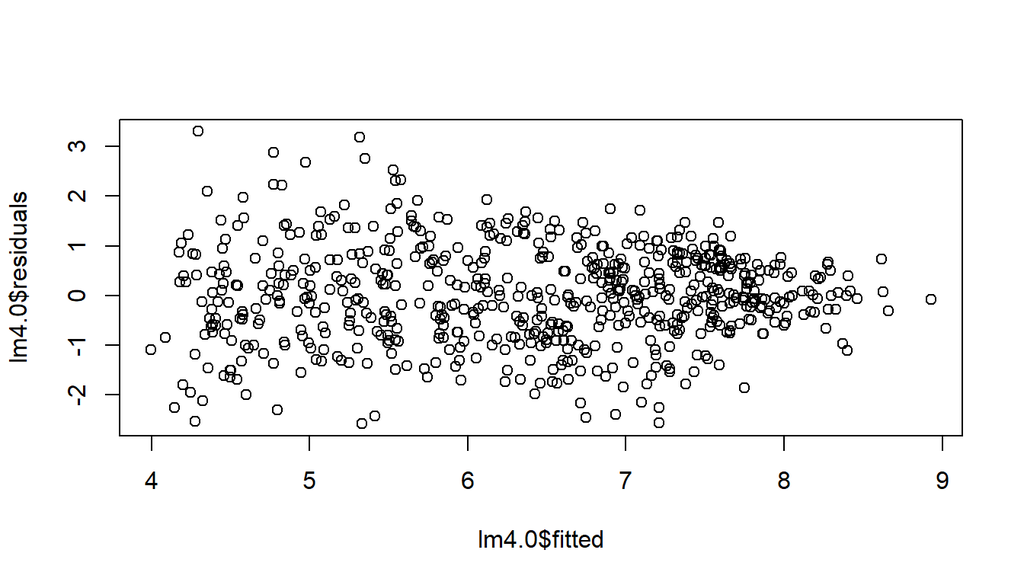

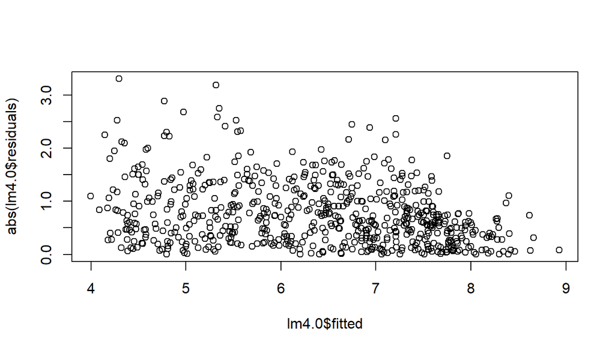

From the two plots it is evident that it is a **Fanning-type pattern** plot. Hence this condition is violated.

**Condition 4: Residuals are independent**

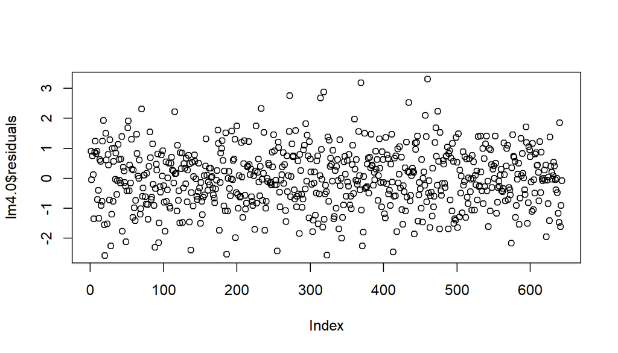

The plot shows a random distribution and since the samples were randomly selected & # of observations of 651 movies is less than 10% of the total # of movies produced until 2016, this condition is met as well.

**Fixing condition 3:**

Similar fix is done as was done in the first part,

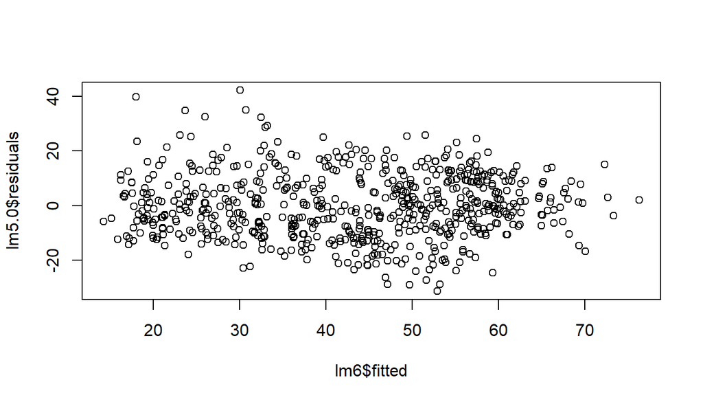

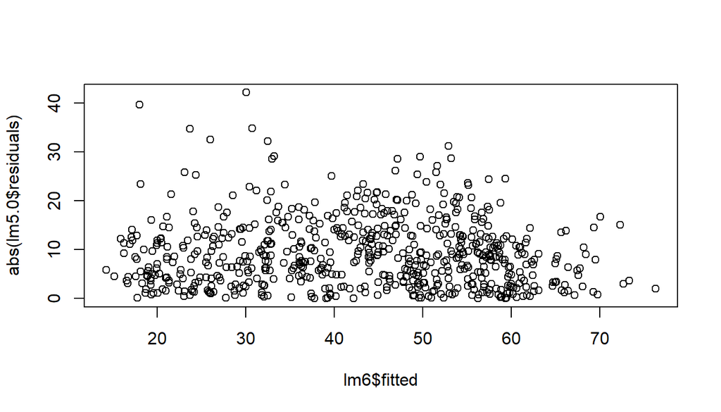

From the above plot it is evident that the condition 3 seems to have improved.